# Danish Monarchs

Marie Kern Larsen

created 4 October 2021, updated 12 May, 2026

```r
knitr::opts_chunk$set(echo = TRUE)
```

The task here is to load your Danish Monarchs csv into R using the `tidyverse` toolkit, calculate and explore the monarchs’ duration of reign with pipes `%>%` in `dplyr` and plot it over time.

## Load the monarchs

Make sure to first create an `.Rproj` workspace with a `data/` folder where you place either your own dataset or the provided `kings.csv` dataset.

1. Look at the dataset that you are loading and check what its columns are separated by? (hint: open it in plain text editor to see)

List what is the

separator: ;

2. Create a `monarchs` object in R with the different functions below and inspect the different outputs.
- `read.csv()`
- `read_csv()`
- `read.csv2()`
- `read_csv2()`

```r
# FILL IN THE CODE BELOW and review the outputs
library(tidyverse)
monarchs1 <- read.csv("data/Danish_monarchs.csv")
head(monarchs1)
```

```
##   name_monach.year_of_birth.year_of_death.start_of_reign.end_of_reign.year_of_birth_uncertain.year_of_death_uncertain.start_of_reign_uncertain.end_of_reign_uncertain
## 1                                                                                                                                          Gorm;NA;958;NA;958;y;n;y;y
## 2                                                                                                                                     Harald_1;NA;987;958;987;y;y;y;y
## 3                                                                                                                                    Svend_1;NA;1014;987;1014;y;n;y;n
## 4                                                                                                                                  Harald_2;NA;1018;1014;1018;y;n;n;n
## 5                                                                                                                                   Knud_1;995;1035;1018;1035;y;n;n;n
## 6                                                                                                                               Hardeknud;1020;1042;1035;1042;n;n;n;n
```

```r
monarchs2 <- read_csv("data/Danish_monarchs.csv",show_col_types = FALSE)
head(monarchs2)
```

```
## # A tibble: 6 × 1
##   name_monach;year_of_birth;year_of_death;start_of_reign;end_of_reign;year_of_…¹
##   <chr>
## 1 Gorm;NA;958;NA;958;y;n;y;y
## 2 Harald_1;NA;987;958;987;y;y;y;y
## 3 Svend_1;NA;1014;987;1014;y;n;y;n
## 4 Harald_2;NA;1018;1014;1018;y;n;n;n
## 5 Knud_1;995;1035;1018;1035;y;n;n;n
## 6 Hardeknud;1020;1042;1035;1042;n;n;n;n
## # ℹ abbreviated name:
## #   ¹`name_monach;year_of_birth;year_of_death;start_of_reign;end_of_reign;year_of_birth_uncertain;year_of_death_uncertain;start_of_reign_uncertain;end_of_reign_uncertain`
```

```r
monarchs3 <- read.csv2("data/Danish_monarchs.csv")
head(monarchs3)
```

```
##   name_monach year_of_birth year_of_death start_of_reign end_of_reign
## 1        Gorm            NA           958             NA          958
## 2    Harald_1            NA           987            958          987
## 3     Svend_1            NA          1014            987         1014
## 4    Harald_2            NA          1018           1014         1018
## 5      Knud_1           995          1035           1018         1035
## 6   Hardeknud          1020          1042           1035         1042
##   year_of_birth_uncertain year_of_death_uncertain start_of_reign_uncertain
## 1                       y                       n                        y
## 2                       y                       y                        y
## 3                       y                       n                        y
## 4                       y                       n                        n
## 5                       y                       n                        n
## 6                       n                       n                        n
##   end_of_reign_uncertain
## 1                      y
## 2                      y
## 3                      n
## 4                      n
## 5                      n
## 6                      n
```

```r
monarchs4 <- read_csv2("data/Danish_monarchs.csv",show_col_types = FALSE)
```

```
## ℹ Using "','" as decimal and "'.'" as grouping mark. Use `read_delim()` for more control.
```

```r
head(monarchs4)
```

```
## # A tibble: 6 × 9
##   name_monach year_of_birth year_of_death start_of_reign end_of_reign
##   <chr>               <dbl>         <dbl>          <dbl>        <dbl>
## 1 Gorm                   NA           958             NA          958
## 2 Harald_1               NA           987            958          987
## 3 Svend_1                NA          1014            987         1014
## 4 Harald_2               NA          1018           1014         1018
## 5 Knud_1                995          1035           1018         1035
## 6 Hardeknud            1020          1042           1035         1042
## # ℹ 4 more variables: year_of_birth_uncertain <chr>,
## #   year_of_death_uncertain <chr>, start_of_reign_uncertain <chr>,
## #   end_of_reign_uncertain <chr>
```

Answer:

1. Which of these functions is a `tidyverse` function? Read data with it below into a `monarchs` object

`read_csv()`and `read_csv2()` are both tidyverse functions, I have chosen `read_csv2()`(the same used for monarchs4) because the dataset is danish and seperated with ;

2. What is the result of running `class()` on the `monarchs` object created with a tidyverse function.

The data is loaded as a tibble and therefore the result is “spec_tbl_df” “tbl_df” “tbl” “data.frame”

3. How many columns does the object have when created with these different functions?

The monarchs objects created with `read.csv()`and `read_csv()` only has 1 column, where as the objects created with `read.csv2()`and `read_csv2()` has 9 columns - this is again because it’s a danish dataset

4. Show the dataset so that we can see how R interprets each column

```r
# COMPLETE THE BLANKS BELOW WITH YOUR CODE, then turn the 'eval' flag in this chunk to TRUE.

monarchs <- read_csv2("data/Danish_monarchs.csv",show_col_types = FALSE)
```

```
## ℹ Using "','" as decimal and "'.'" as grouping mark. Use `read_delim()` for more control.
```

```r
class(monarchs)
```

```
## [1] "spec_tbl_df" "tbl_df"      "tbl"         "data.frame"
```

```r
ncol(monarchs1)
```

```
## [1] 1
```

```r
ncol(monarchs2)
```

```
## [1] 1
```

```r
ncol(monarchs3)
```

```
## [1] 9
```

```r
ncol(monarchs4)
```

```
## [1] 9
```

```r
glimpse(monarchs)
```

```
## Rows: 55
## Columns: 9
## $ name_monach              <chr> "Gorm", "Harald_1", "Svend_1", "Harald_2", "K…
## $ year_of_birth            <dbl> NA, NA, NA, NA, 995, 1020, 1024, NA, NA, NA, …
## $ year_of_death            <dbl> 958, 987, 1014, 1018, 1035, 1042, 1047, 1076,…
## $ start_of_reign           <dbl> NA, 958, 987, 1014, 1018, 1035, 1042, 1047, 1…
## $ end_of_reign             <dbl> 958, 987, 1014, 1018, 1035, 1042, 1047, 1074,…
## $ year_of_birth_uncertain  <chr> "y", "y", "y", "y", "y", "n", "n", "y", "y", …
## $ year_of_death_uncertain  <chr> "n", "y", "n", "n", "n", "n", "n", "n", "n", …
## $ start_of_reign_uncertain <chr> "y", "y", "y", "n", "n", "n", "n", "n", "n", …
## $ end_of_reign_uncertain   <chr> "y", "y", "n", "n", "n", "n", "n", "n", "n", …
```

## Calculate the duration of reign for all the monarchs in your table

You can calculate the duration of reign in years with `mutate` function by subtracting the equivalents of your `startReign` from `endReign` columns and writing the result to a new column called `duration`. But first you need to check a few things:

- Is your data messy? Fix it before re-importing to R
- Do your start and end of reign columns contain NAs? Choose the right strategy to deal with them: `na.omit()`, `na.rm=TRUE`, `!is.na()`

Create a new column called `duration` in the monarchs dataset, utilizing the `mutate()` function from tidyverse. Check with your group to brainstorm the options.

```r
# YOUR CODE
monarchs %>%
  mutate(duration=end_of_reign-start_of_reign) %>%
  select(name_monach,duration)
```

```
## # A tibble: 55 × 2
##    name_monach duration
##    <chr>          <dbl>
##  1 Gorm              NA
##  2 Harald_1          29
##  3 Svend_1           27
##  4 Harald_2           4
##  5 Knud_1            17
##  6 Hardeknud          7
##  7 Magnus             5
##  8 Svend_2           27
##  9 Harald_3           6
## 10 Knud_2             6
## # ℹ 45 more rows
```

## Calculate the average duration of reign for all rulers

Do you remember how to calculate an average on a vector object? If not, review the last two lessons and remember that a column is basically a vector. So you need to subset your `monarchs` dataset to the `duration` column. If you subset it as a vector you can calculate average on it with `mean()` base-R function. If you subset it as a tibble, you can calculate average on it with `summarize()` tidyverse function. Try both ways!

- You first need to know how to select the relevant `duration` column. What are your options?
- Is your selected `duration` column a tibble or a vector? The `mean()` function can only be run on a vector. The `summarize()` function works on a tibble.
- Are you getting an error that there are characters in your column? Coerce your data to numbers with `as.numeric()`.
- Remember to handle NAs: `mean(X, na.rm=TRUE)`

```r
# YOUR CODE
monarchs %>%
  mutate(duration=end_of_reign-start_of_reign) %>%
  summarize(mean_duration=mean(duration,na.rm=TRUE))
```

```
## # A tibble: 1 × 1
##   mean_duration
##           <dbl>
## 1          20.3
```

## How many and which monarchs enjoyed a longer-than-average duration of reign?

You have calculated the average duration above. Use it now to `filter()` the `duration` column in `monarchs` dataset. Display the result and also count the resulting rows with `count()`

```r
# YOUR CODE
monarchs %>%
  mutate(duration=end_of_reign-start_of_reign) %>%
  select(name_monach, duration) %>%
  filter(duration>mean(duration,na.rm=TRUE)) %>%
  count()
```

```
## # A tibble: 1 × 1
##       n
##   <int>
## 1    24
```

```r
monarchs %>%
  mutate(duration=end_of_reign-start_of_reign) %>%
  select(name_monach, duration) %>%
  filter(duration>mean(duration,na.rm=TRUE))
```

```
## # A tibble: 24 × 2
##    name_monach duration
##    <chr>          <dbl>
##  1 Harald_1          29
##  2 Svend_1           27
##  3 Svend_2           27
##  4 Niels             30
##  5 Valdemar_1        36
##  6 Valdemar_2        39
##  7 Erik_5            27
##  8 Erik_6            33
##  9 Valdemar_4        35
## 10 Erik_7            43
## # ℹ 14 more rows
```

## How many days did the three longest-ruling monarchs rule?

- Sort monarchs by reign `duration` in the descending order. Select the three longest-ruling monarchs with the `slice()` function
- Use `mutate()` to create `Days` column where you calculate the total number of days they ruled
- BONUS: consider the transition year (with 366 days) in your calculation!

```r
# YOUR CODE
monarchs %>%
  mutate(duration=end_of_reign-start_of_reign) %>%
  mutate(days=duration*365) %>%
  select(name_monach, duration,days) %>%
  arrange(desc(duration)) %>%
  slice(1:3)
```

```
## # A tibble: 3 × 3
##   name_monach duration  days
##   <chr>          <dbl> <dbl>
## 1 Christian_4       60 21900
## 2 Margrethe_2       52 18980
## 3 Erik_7            43 15695
```

## Challenge: Plot the monarchs’ duration of reign through time

What is the long-term trend in the duration of reign among Danish monarchs? How does it relate to the historical violence trends ?

- Try to plot the duration of reign column in `ggplot` with `geom_point()` and `geom_smooth()`
- In order to peg the duration (which is between 1-99) somewhere to the x axis with individual centuries, I recommend creating a new column `midyear` by adding to `startYear` the product of `endYear` minus the `startYear` divided by two (`startYear + (endYear-startYear)/2`).
- Now you can plot the monarchs dataset, plotting `midyear` along the x axis and `duration` along y axis
- BONUS: add a title, nice axis labels to the plot and make the theme B&W and font bigger to make it nice and legible!

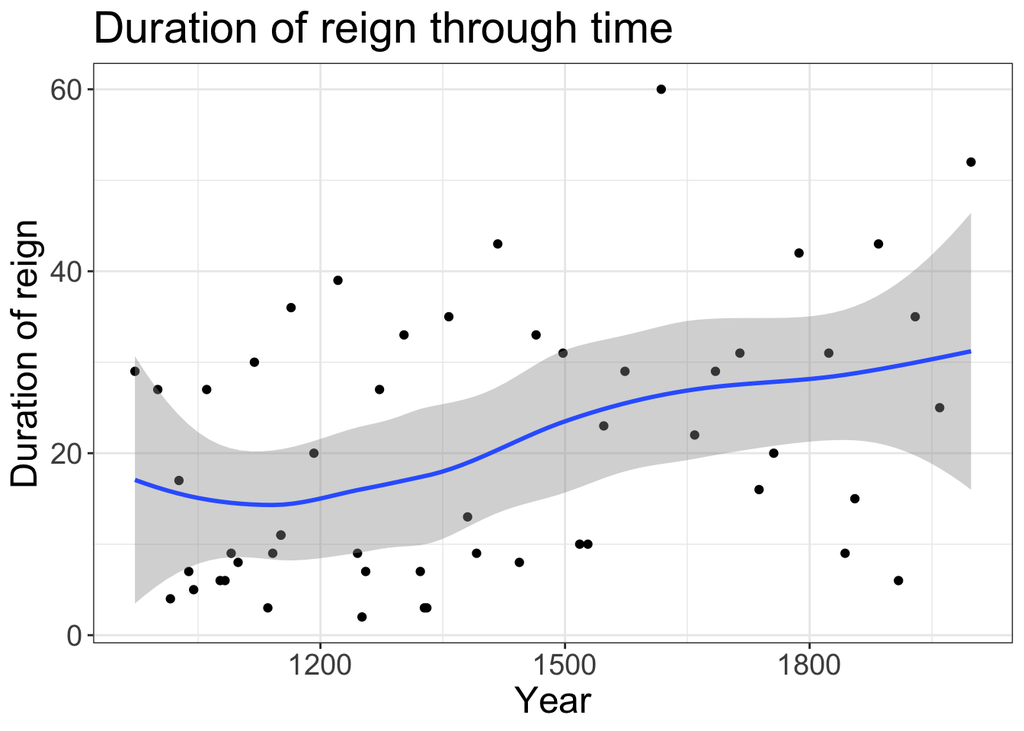

```r
# YOUR CODE
monarchs_plotting <- monarchs

monarchs_plotting %>%
  mutate(duration=end_of_reign-start_of_reign) %>%
  mutate(midyear=start_of_reign+(end_of_reign-start_of_reign)/2) %>%
  ggplot(aes(x=midyear,y=duration))+ geom_point()+geom_smooth()+labs(title="Duration of reign through time",x="Year", y="Duration of reign")+ theme_bw()+theme(text=element_text(size=18))
```

And to submit this rmarkdown, knit it into html. But first, clean up the code chunks, adjust the date, rename the author and change the `eval=FALSE` flag to `eval=TRUE` so your script actually generates an output. Well done!